# Midterm

Author

Oscar Lam

## Introduction

Youth substance use remains a critical public health challenge, with smoking during adolescence associated with increased risks of addiction and adverse health outcomes in adulthood. Understanding the factors that influence smoking behavior among young people is essential for developing targeted prevention strategies.

While numerous individual and environmental factors have been hypothesizsd to influence youth smoking behaviors, such as socioeconomic conditions, peer relationships, family dynamics, and access to prevention programs, the relative importance of these factors remains an active area of inquiry.

The primary question guiding this analysis is: **Which social factor has the strongest influence on youth smoking prevalence?**The analysis considers social factors as the teen’s socioeconomic status, peer influence, family background, and parental supervision. By comparing the relative effects of the social factors, this project demonstrates key data science techniques including data wrangling, exploratory data analysis, statistical visualisation, and comparative analysis that are relevant to public health research. While the dataset used is synthetic, the analytical approaches demonstrated here can be directly applied to real clinical or experimental datasets in public health research settings.

## Data Preparation

### Data Source & Acquisition

The dataset used in this analysis was obtained from Kaggle, titled “Youth Smoking and Drug Dataset: An In-depth Look at Trends in Youth Substance Use (2020-2024).” It is worth noting that this synthetic dataset was created for educational purposes and contains approximately 10,000 AI-generated records simulating trends in youth smoking and drug experimentation from 2020 to 2024.

The dataset contains 15 variables covering age groups (10-80+ years), gender, smoking prevalence, drug experimentation rates, socioeconomic status, peer influence, school programs, family background, mental health indicators, access to counseling, parental supervision, substance education, community support, and media influence.

### Data Import & Initial Preview

```r
library(tidyverse)
library(knitr)

df_smoke <- read_csv("youth_smoking_drug_data.csv")
cat("Dataset contains", nrow(df_smoke), "observations and", ncol(df_smoke), "variables.")
```

```
Dataset contains 10000 observations and 15 variables.
```

### Data Cleaning & Wrangling

Given that the data set has a wide range of age included, a cleaned data has been made by filtering the age group to the individual between 10-14 and 15-19 while also converting categorical variables to factors with appropriate levels and ensuring that all numeric variables are properly stored as numeric.

```r
youth_clean <- df_smoke %>%
  filter(Age_Group %in% c("10-14", "15-19")) %>%
  select(Year, Age_Group, Gender, Smoking_Prevalence, Peer_Influence, Family_Background, Parental_Supervision, Socioeconomic_Status) %>%
  mutate(
    Age_Group= factor(Age_Group, levels = c("10-14", "15-19")),
    Gender= factor(Gender, levels = c("Male", "Female", "Both")),
    Socioeconomic_Status = factor(Socioeconomic_Status, levels = c("Low", "Middle", "High")),
  ) %>%
  mutate(
    Year= as.integer(Year),
    Smoking_Prevalence = as.numeric(Smoking_Prevalence),
    Peer_Influence= as.integer(Peer_Influence),
    Family_Background= as.integer(Family_Background),
    Parental_Supervision= as.integer(Parental_Supervision)
  )

cat("Cleaned dataset for youth (ages 10-19):\n")
```

```
Cleaned dataset for youth (ages 10-19):
```

```r
cat("Total observations:",nrow(youth_clean), "\n")
```

```
Total observations: 2021
```

```r
cat("Variables included:",ncol(youth_clean), "\n")
```

```
Variables included: 8
```

```r
cat("Time period:", min(youth_clean$Year), "-", max(youth_clean$Year), "\n")
```

```
Time period: 2020 - 2024
```

During data cleaning and wrangling, this analysis also checks for missing values:

```r
missing_summary <- youth_clean %>%
  summarise(across(everything(), ~sum(is.na(.)))) %>%
  pivot_longer(everything(), names_to = "Variable", values_to = "Missing_Count") %>%
  filter(Missing_Count > 0)

if(nrow(missing_summary) == 0) {
  cat("\nNo missing values detected in the dataset.\n")
} else {
  cat("\nMissing values found:\n")
  print(missing_summary)
}
```

```
No missing values detected in the dataset.
```

## Exploratory Analysis

### Dataset Characteristics

The analysis begins by examining the structure and characteristics of the cleaned dataset and ensure that all types are correctly handled earlier.

```r
variable_info <- data.frame(
  Variable= names(youth_clean),
  Type = sapply(youth_clean, function(x) class(x)[1]),
  row.names = NULL
) %>%
  mutate(
    Type= case_when(
      Type == "integer" ~ "Integer",
      Type == "numeric" ~ "Numeric",
      Type == "factor" ~ "Factor",
      TRUE ~ Type
    )
  )

kable(variable_info, caption = "Variables in the Youth Smoking Dataset")
```

Variables in the Youth Smoking Dataset

| Variable | Type |
| --- | --- |
| Year | Integer |
| Age_Group | Factor |
| Gender | Factor |
| Smoking_Prevalence | Numeric |
| Peer_Influence | Integer |
| Family_Background | Integer |
| Parental_Supervision | Integer |
| Socioeconomic_Status | Factor |

### Data Structure

```r
kable(head(youth_clean,6), caption= "First 6 Observations", digits= 2)
```

First 6 Observations

| Year | Age_Group | Gender | Smoking_Prevalence | Peer_Influence | Family_Background | Parental_Supervision | Socioeconomic_Status |
| --- | --- | --- | --- | --- | --- | --- | --- |
| 2024 | 15-19 | Both | 18.85 | 5 | 1 | 4 | High |
| 2024 | 10-14 | Female | 34.88 | 6 | 10 | 9 | High |
| 2023 | 10-14 | Both | 42.00 | 6 | 2 | 2 | High |
| 2023 | 15-19 | Male | 47.90 | 1 | 2 | 4 | High |
| 2022 | 10-14 | Female | 7.87 | 5 | 9 | 4 | Middle |
| 2020 | 15-19 | Male | 11.78 | 9 | 1 | 2 | Low |

```r
kable(tail(youth_clean,6), caption= "Last 6 Observations", digits= 2)
```

Last 6 Observations

| Year | Age_Group | Gender | Smoking_Prevalence | Peer_Influence | Family_Background | Parental_Supervision | Socioeconomic_Status |
| --- | --- | --- | --- | --- | --- | --- | --- |
| 2023 | 10-14 | Female | 37.67 | 1 | 2 | 9 | High |
| 2021 | 15-19 | Male | 26.23 | 6 | 4 | 1 | High |
| 2020 | 15-19 | Male | 45.54 | 9 | 1 | 1 | Middle |
| 2023 | 15-19 | Both | 5.81 | 3 | 2 | 2 | Low |
| 2023 | 15-19 | Male | 49.17 | 7 | 4 | 7 | Low |
| 2023 | 10-14 | Male | 43.77 | 4 | 3 | 1 | High |

### Distribution of Key Variables

#### Summary Statistics for Continuous Variables

```r
sum_stat <- youth_clean %>%
  select(Smoking_Prevalence, Peer_Influence, Family_Background, Parental_Supervision) %>%
  pivot_longer(everything(), names_to = "Variable", values_to = "Value") %>%
  group_by(Variable) %>%
  summarise(
    Num_of_Obs = n(),
    Mean= mean(Value),
    Median= median(Value),
    SD = sd(Value),
    Min= min(Value),
    Max= max(Value),
    .groups = 'drop'
  )

kable(sum_stat, digits = 2, caption = "Summary Statistics for Continuous Variables")
```

Summary Statistics for Continuous Variables

| Variable | Num_of_Obs | Mean | Median | SD | Min | Max |
| --- | --- | --- | --- | --- | --- | --- |
| Family_Background | 2021 | 5.59 | 6.00 | 2.84 | 1.00 | 10 |
| Parental_Supervision | 2021 | 5.43 | 6.00 | 2.89 | 1.00 | 10 |
| Peer_Influence | 2021 | 5.41 | 5.00 | 2.84 | 1.00 | 10 |
| Smoking_Prevalence | 2021 | 27.77 | 27.89 | 12.95 | 5.02 | 50 |

All four continuous variables have 2021 observations each. Smoking prevalence has a mean of 27.8% with a great variability (SD=12.95), while other factors have a similar central tendencies around 5.4-5.6 on the scale.

#### Distribution of Smoking Prevalence

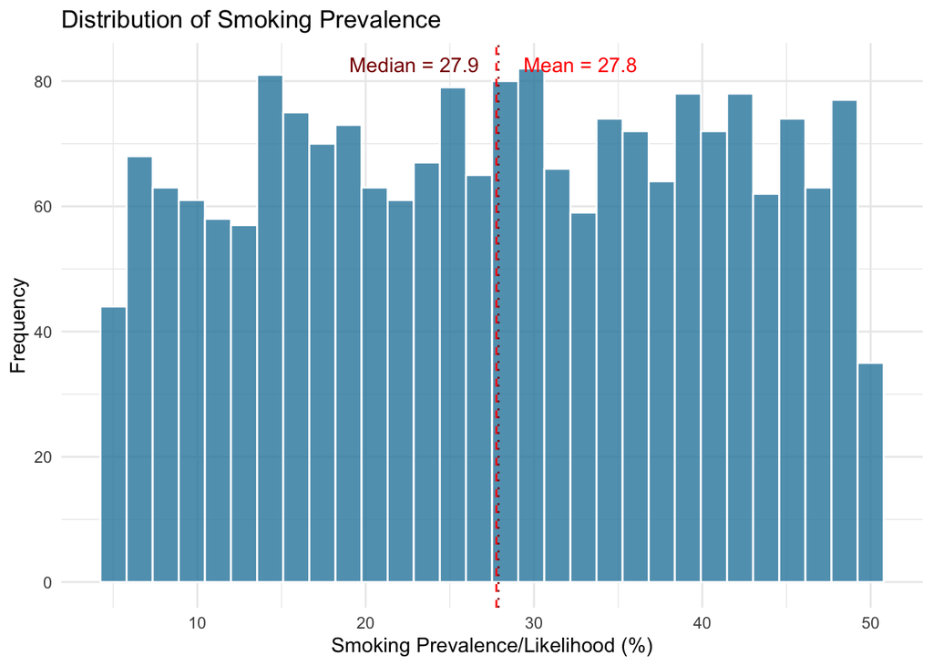

```r
mean_smoking <- mean(youth_clean$Smoking_Prevalence)
median_smoking <- median(youth_clean$Smoking_Prevalence)

ggplot(youth_clean, aes(x= Smoking_Prevalence)) +
  geom_histogram(bins = 30, fill= "#2E86AB", color= "white", alpha= 0.8) +
  geom_vline(xintercept = mean_smoking, linetype = "dashed", color = "red") +
  geom_vline(xintercept = median_smoking, linetype = "dotted", color = "darkred") +
  annotate("text", x = mean_smoking + 5, y = Inf, vjust = 2,
           label = paste("Mean =", round(mean_smoking, 1)), color = "red") +
  annotate("text", x = median_smoking - 5, y = Inf, vjust = 2,
           label = paste("Median =", round(median_smoking, 1)), color = "darkred") +
  labs(title= "Distribution of Smoking Prevalence",
       x= "Smoking Prevalence/Likelihood (%)",
       y= "Frequency") +
  theme_minimal()
```

Smoking prevalence shows pretty uniform distribution with a mean of 27.8% and a median of 27.9%, suggesting a symmetric distribution. The spread also suggests considerable variation in smoking rates among the teen.

#### Social Factors Distribution

#### Peer Influence

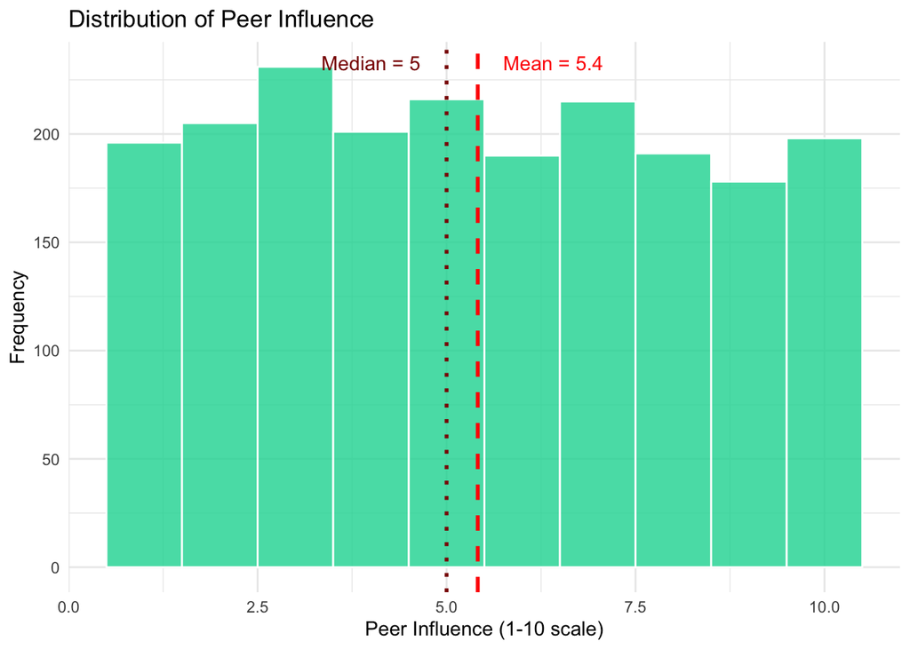

```r
mean_peer <- mean(youth_clean$Peer_Influence)
median_peer <- median(youth_clean$Peer_Influence)

ggplot(youth_clean, aes(x= Peer_Influence)) +
  geom_histogram(bins=10, fill= "#06D6A0", color = "white", alpha = 0.8) +
  geom_vline(xintercept= mean_peer, linetype = "dashed", color = "red", linewidth = 1) +
  geom_vline(xintercept= median_peer, linetype = "dotted", color = "darkred", linewidth = 1) +
  annotate("text", x= mean_peer + 1, y= Inf, vjust= 2,
           label = paste("Mean =", round(mean_peer, 1)), color = "red") +
  annotate("text", x =median_peer - 1, y= Inf, vjust= 2,
           label = paste("Median =", round(median_peer, 1)), color = "darkred") +
  labs(title = "Distribution of Peer Influence",
       x = "Peer Influence (1-10 scale)",
       y = "Frequency") +
  theme_minimal()
```

Peer influence shows an uniform distribution with a mean of 5.4 and a median of 5, suggesting a balanced representation of peer influence in the data.

#### Family Background

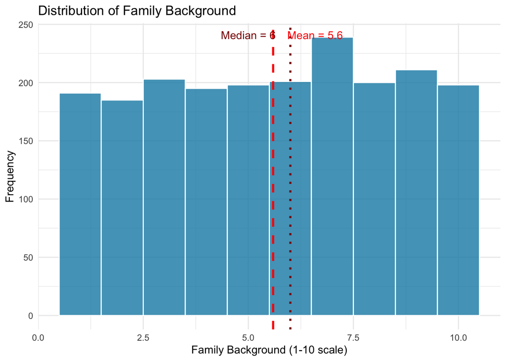

```r
mean_family <- mean(youth_clean$Family_Background)
median_family <- median(youth_clean$Family_Background)

ggplot(youth_clean, aes(x= Family_Background)) +
  geom_histogram(bins=10, fill= "#118AB2", color = "white", alpha = 0.8) +
  geom_vline(xintercept= mean_family, linetype = "dashed", color = "red", linewidth = 1) +
  geom_vline(xintercept= median_family, linetype = "dotted", color = "darkred", linewidth = 1) +
  annotate("text", x= mean_family + 1, y = Inf, vjust= 2,
           label = paste("Mean =", round(mean_family, 1)), color = "red") +
  annotate("text", x= median_family - 1, y = Inf, vjust= 2,
           label = paste("Median =", round(median_family, 1)), color = "darkred") +
  labs(title = "Distribution of Family Background",
       x = "Family Background (1-10 scale)",
       y = "Frequency") +
  theme_minimal()
```

The family background also shows a similar uniform distribution with a slight increase on the higher end of values (7-9 range). The distribution has a median of 6 and a mean of 5.6.

#### Parental Supervision

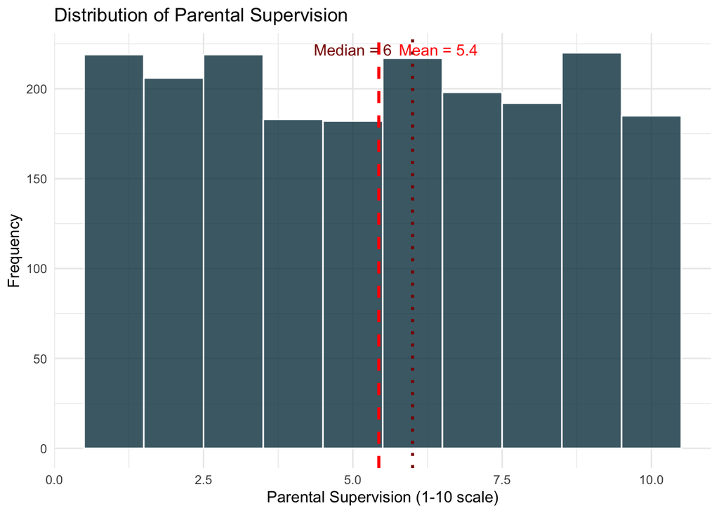

```r
mean_parental <- mean(youth_clean$Parental_Supervision)
median_parental <- median(youth_clean$Parental_Supervision)

ggplot(youth_clean, aes(x= Parental_Supervision)) +
  geom_histogram(bins=10, fill= "#073B4C", color = "white", alpha = 0.8) +
  geom_vline(xintercept= mean_parental, linetype = "dashed", color = "red", linewidth = 1) +
  geom_vline(xintercept= median_parental, linetype = "dotted", color = "darkred", linewidth = 1) +
  annotate("text", x= mean_parental + 1, y= Inf, vjust= 2,
           label = paste("Mean =", round(mean_parental, 1)), color = "red") +
  annotate("text", x= median_parental - 1, y = Inf, vjust= 2,
           label = paste("Median =", round(median_parental, 1)), color = "darkred") +
  labs(title = "Distribution of Parental Supervision",
       x = "Parental Supervision (1-10 scale)",
       y = "Frequency") +
  theme_minimal()
```

Parental supervision also has a relatively uniform distribution with a slight peak at the lower end (1-3), it also comes with a median of 6 and a mean of 5.4.

#### Socioeconomic Status

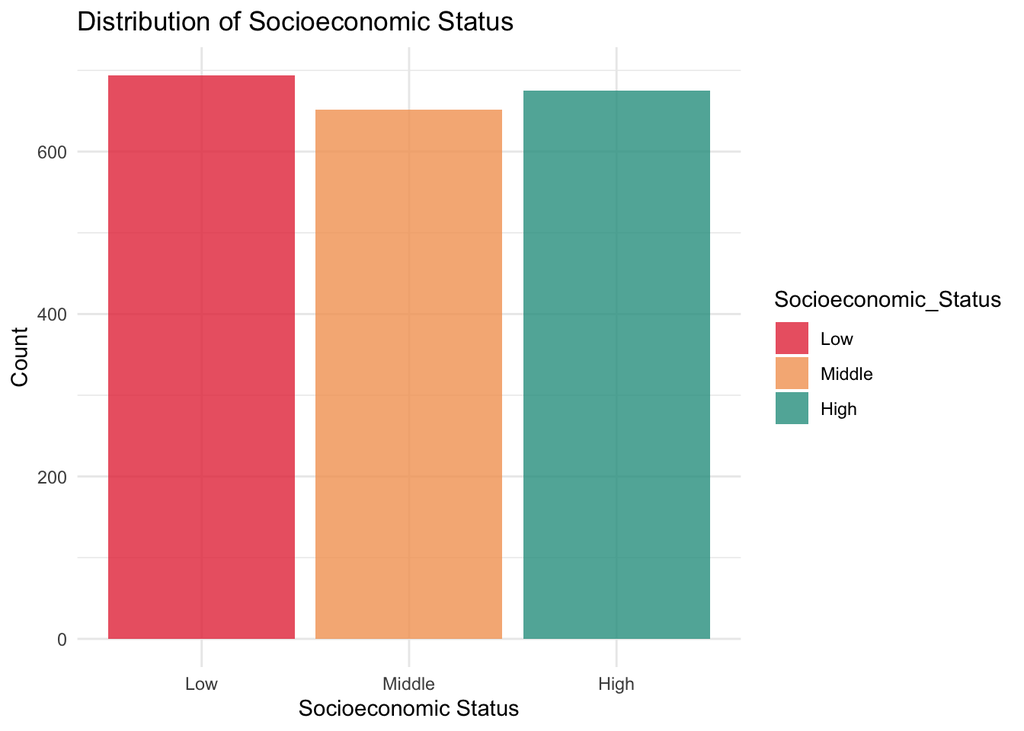

```r
ggplot(youth_clean, aes(x=Socioeconomic_Status, fill= Socioeconomic_Status)) +
  geom_bar(alpha= 0.8) +
  scale_fill_manual(values= c("Low" = "#E63946", "Middle" = "#F4A261", "High" = "#2A9D8F")) +
  labs(title = "Distribution of Socioeconomic Status",
       x= "Socioeconomic Status",
       y= "Count") +
  theme_minimal()
```

The socioeconomic status is evenly distributed across the three category with a slightly lower count fro the middle status, all hovering around 650 observation per group.

## Preliminary Results

The preliminary analysis begins with a correlation matrix of all variables.

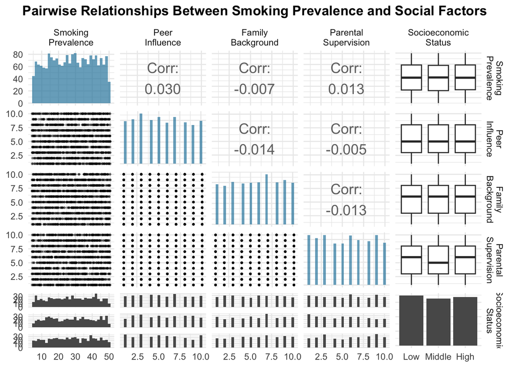

```r
library(GGally)
library(kableExtra)

youth_clean %>%
  select(Smoking_Prevalence, Peer_Influence, Family_Background, Parental_Supervision, Socioeconomic_Status) %>%
  ggpairs(
    title = "Pairwise Relationships Between Smoking Prevalence and Social Factors",
    columnLabels = c("Smoking\nPrevalence", "Peer\nInfluence", "Family\nBackground", "Parental\nSupervision", "Socioeconomic\nStatus"),
    upper= list(continuous= wrap("cor", size = 5)),
    lower= list(continuous= wrap("points", alpha = 0.3, size = 0.5)),
    diag= list(continuous= wrap("barDiag", fill = "#2E86AB", alpha = 0.7))
  ) +
  theme_minimal() +
  theme(plot.title = element_text(face = "bold", hjust = 0.5))
```

The matrix shows very weak linear relationship between all social factors and smoking prevalence, with peer influence having the highest correlation of 0.03. The scatter plots in the lower triangle also shows no clear patterns.

### Socioeconomic Status

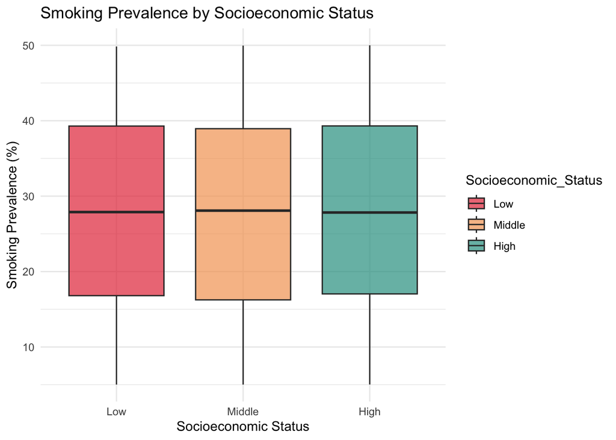

```r
ggplot(youth_clean, aes(x= Socioeconomic_Status, y= Smoking_Prevalence, fill = Socioeconomic_Status)) +
  geom_boxplot(alpha = 0.7, outlier.size = 2, outlier.alpha = 0.5) +
  scale_fill_manual(values= c("Low" = "#E63946", "Middle" = "#F4A261", "High" = "#2A9D8F")) +
  labs(title= "Smoking Prevalence by Socioeconomic Status",
       x= "Socioeconomic Status",
       y= "Smoking Prevalence (%)") +
  theme_minimal()
```

When zooming into the effect of socioeconomic status, the boxplot shows similar smoking prevalence across all three socioeconomic status with a prevalence % of around 28% for all three status. The boxplot suggests a very minimal association between socioeconomic status and smoking prevalence in this dataset.

### Continuous Social Factor Analysis

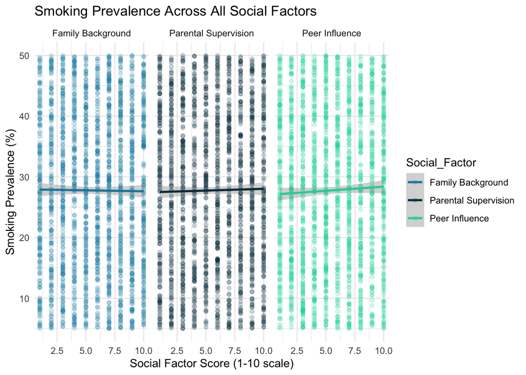

```r
youth_combined <- youth_clean %>%
  select(Smoking_Prevalence, Peer_Influence, Family_Background, Parental_Supervision) %>%
  pivot_longer(cols= c(Peer_Influence, Family_Background, Parental_Supervision),
               names_to = "Social_Factor",
               values_to = "Score") %>%
  mutate(Social_Factor= case_when(
    Social_Factor == "Peer_Influence" ~ "Peer Influence",
    Social_Factor == "Family_Background" ~ "Family Background",
    Social_Factor == "Parental_Supervision" ~ "Parental Supervision"
  ))

ggplot(youth_combined, aes(x= Score, y= Smoking_Prevalence, color= Social_Factor)) +
  geom_point(alpha = 0.2, size = 1.5) +
  geom_smooth(method = "lm", se = TRUE) +
  scale_color_manual(values = c("Peer Influence" = "#06D6A0",
                                 "Family Background" = "#118AB2",
                                 "Parental Supervision" = "#073B4C")) +
  facet_wrap(~ Social_Factor, ncol = 3) +
  labs(title = "Smoking Prevalence Across All Social Factors",
       x = "Social Factor Score (1-10 scale)",
       y = "Smoking Prevalence (%)") +
  theme_minimal()
```

When examining the effect of the three continuous social factor on smoking prevalence, it reinforces our early observation in the matrix that all of them have nearly flat fitted line, suggesting minimal correlation. Peer influence has the most inclined line among three, affirming our early observation.

### Summary Statistics

#### Correlation Summary Table

```r
cor_peer <- cor(youth_clean$Peer_Influence, youth_clean$Smoking_Prevalence)
cor_family <- cor(youth_clean$Family_Background, youth_clean$Smoking_Prevalence)
cor_parental <- cor(youth_clean$Parental_Supervision, youth_clean$Smoking_Prevalence)

correlation_summary <- data.frame(
  Social_Factor= c("Peer Influence", "Family Background", "Parental Supervision"),
  Correlation= c(cor_peer, cor_family, cor_parental)
) %>%
  arrange(desc(abs(Correlation)))

kable(correlation_summary,
      digits= 3,
      caption = "Correlation Coefficients with Smoking Prevalence",
      col.names = c("Social Factor", "Correlation Coefficient"))
```

Correlation Coefficients with Smoking Prevalence

| Social Factor | Correlation Coefficient |
| --- | --- |
| Peer Influence | 0.030 |
| Parental Supervision | 0.013 |
| Family Background | -0.007 |

From the correlation coefficient table, once again it shows that peer influence has the strongest association (r = 0.030), though this remains negligible in practical terms. All three social factors demonstrate correlations very close to zero, indicating that none of these variables show meaningful linear relationships with smoking prevalence in this synthetic dataset.

```r
ses_summary <- youth_clean %>%
  group_by(Socioeconomic_Status) %>%
  summarise(
    Num_of_Obs = n(),
    Mean = mean(Smoking_Prevalence),
    Median = median(Smoking_Prevalence),
    SD = sd(Smoking_Prevalence),
    .groups = 'drop'
  )

kable(ses_summary, digits = 2, caption = "Smoking Prevalence by Socioeconomic Status", col.names = c("Socioeconomic Status", "Num of Obs", "Mean (%)", "Median (%)", "SD"))
```

Smoking Prevalence by Socioeconomic Status

| Socioeconomic Status | Num of Obs | Mean (%) | Median (%) | SD |
| --- | --- | --- | --- | --- |
| Low | 694 | 27.67 | 27.89 | 12.89 |
| Middle | 652 | 27.86 | 28.08 | 13.03 |
| High | 675 | 27.77 | 27.83 | 12.94 |

The summary statistics confirm the visual impression from the boxplot, with mean smoking prevalence nearly identical across Low (27.67%), Middle (27.86%), and High (27.77%) socioeconomic groups. The similar standard deviations (approximately 13%) further indicate homogeneous distributions, suggesting socioeconomic status is not associated with differences in smoking prevalence.

### Follow-up Questions

The preliminary analysis revealed surprisingly weak association between all examined social factors and smoking prevalence with near zero correlation coefficients and minimal difference between socioeconomic groups. The following follow-up questions have been prompted for further analysis:

1. Are there confounding variables/effects not being examined in this analysis? Could there potentially be confounding effect from other variables in the dataset (such as mental health) that will change the coefficient correlations?
2. Are there interaction effects between the social factors? The current analysis examines each social factor independently. Could socioeconomic status have an interactive effect?
3. Is there any temporal variation? The dataset spans from 2020 to 2024, including the period of COVID pandemic. Could the period of survey affect the result?

## Conclusion

This analysis examined, among peer influence, family background, parental supervision, or socioeconomic status, which social factors have the strongest association with smoking prevalence among youth aged 10-19 using a synthetic dataset of 2,021 observations from 2020-2024. The investigation employed correlation analysis, visualisation techniques, and descriptive statistics to compare the relative influence of these factors.

The findings showed surprisingly weak associations between all examined social factors and smoking prevalence. Correlation coefficients for the three continuous variables ranged from -0.007 to 0.030, all effectively zero. Similarly, socioeconomic status showed nearly identical mean smoking prevalence across low (27.67%), middle (27.86%), and high (27.77%) groups, indicating minimal categorical differences. These results suggest that none of the examined social factors demonstrate meaningful predictive relationships with youth smoking behavior in this dataset.

Several limitations should be considered when interpreting these findings. Most importantly, this analysis used entirely synthetic data designed for educational purposes, which may not accurately reflect real-world relationships between social factors and smoking behavior. The weak associations observed could result from how the data were generated rather than representing true patterns. Additionally, the analysis examined factors independently without considering potential interaction effects or confounding by unmeasured variables such as mental health.

Despite these limitations, this project demonstrated essential data science skills applicable to public health research, including data wrangling, exploratory data analysis, correlation analysis, and publication-quality visualisation. When applied to authentic datasets, these techniques can be used to enable researchers to identify meaningful risk factors and inform evidence-based prevention strategies.

Future analyses could strengthen these findings by examining interaction effects between social factors using multiple regression and the confounding effect by incorporating additional variables present in the dataset. An ANOVA approach could more rigorously test whether socioeconomic status differences remain when controlling for other factors. However, the fundamental limitation remains that insightful conclusions about youth smoking determinants require validation with real-world clinical or survey data collected from actual adolescent populations.